# Detecting mistakes in weight-lifting exercises by using activity recognition techniques

Lance Bryant

July 19, 2014

# 1 Introduction

Using data collected by Groupware@LES, we build a model to detect mistakes (if any) for individuals performing unilateral dumbbell bicep curls. The data was collected from four 9 degrees of freedom Razor inertial measurement units (IMU), which provide three-axes acceleration, gyroscope and magnetometer data. These sensors were mounted in the users’ glove, armband, lumbar belt and dumbbell. We find that from this data, we can accurately predict if an individual is performing the exercise correctly, or making a mistake such as throwing the elbows to the front, lifting the dumbbell only halfway, lowering the dumbbell only halfway, or throwing the hips to the front.

# 2 Data

We begin by loading the necessary libraries and data.

```r
library(caret)
set.seed(126)
```

```r
train <- read.csv("pml-training.csv", na.strings=c("NA", ""))
test_final <- read.csv("pml-testing.csv", na.strings=c("NA", ""))
dim(train); dim(test_final)
```

```
## [1] 19622   160
```

```
## [1]  20 160
```

We see from above that the training set has 160 variables for each of the 19,622 times the measurements of the sensors were recorded; whereas, the testing set consists of a small sample of 20 times. The exercises were performed by six male participants aged between 20-28 years, with little weight lifting experience. The table below shows how many times the measurements were taken for each participant.

```r
table(train$user_name, train$classe)
```

```
##
##               A    B    C    D    E
##   adelmo   1165  776  750  515  686
##   carlitos  834  690  493  486  609
##   charles   899  745  539  642  711
##   eurico    865  592  489  582  542
##   jeremy   1177  489  652  522  562
##   pedro     640  505  499  469  497
```

Inspection of the data reveals that many variables consist of a high number of `NA` values. We remove these variables from the dataset along with variables that have no bearing on the exercises (user name, time of measurement, etc.)

```r
table(colSums(is.na(train))); table(colSums(is.na(test_final)))
```

```
##
##     0 19216
##    60   100
```

```
##
##   0  20
##  60 100
```

```r
train_clean <- train[-c(1:7)]
train_clean <- train_clean[,colSums(is.na(train_clean)) == 0]
```

# 3 Building the model

In this section, we build a machine learning model for predicting the `classe` value based on the other features of the dataset. We use a random forest machine learning technique. First we partition our cleaned training set, and then build the model.

```r
inTrain = createDataPartition(y = train_clean$classe, p = 0.6, list = FALSE)
train_small <- train_clean[inTrain,]
test_small <- train_clean[-inTrain,]
```

```r
modfit <- train(classe ~ ., data = train_small, method = "rf", prox = TRUE,
                trControl = trainControl(method = "cv", number = 4))
```

Below is a summary of the model.

```r
modfit
```

```
## Random Forest
##
## 11776 samples
##    52 predictors
##     5 classes: 'A', 'B', 'C', 'D', 'E'
##
## No pre-processing
## Resampling: Cross-Validated (4 fold)
##
## Summary of sample sizes: 8832, 8833, 8832, 8831
##
## Resampling results across tuning parameters:
##
##   mtry  Accuracy  Kappa  Accuracy SD  Kappa SD
##   2     1         1      0.002        0.003
##   30    1         1      9e-04        0.001
##   50    1         1      0.003        0.003
##
## Accuracy was used to select the optimal model using  the largest value.
## The final value used for the model was mtry = 2.
```

Below we display two confusion matrices and related statistics. The first shows that the in-sample accuracy of our model is 100%. The second shows the out-of-sample accuracy is between 98.7% and 99.2% at the 95%-confidence level.

```r
train_small_pred <- predict(modfit, train_small)
test_small_pred <- predict(modfit, test_small)
confusionMatrix(train_small_pred, train_small$classe)
```

```
## Confusion Matrix and Statistics
##
##           Reference
## Prediction    A    B    C    D    E
##          A 3348    0    0    0    0
##          B    0 2279    0    0    0
##          C    0    0 2054    0    0
##          D    0    0    0 1930    0
##          E    0    0    0    0 2165
##
## Overall Statistics
##
##                Accuracy : 1
##                  95% CI : (1, 1)
##     No Information Rate : 0.284
##     P-Value [Acc > NIR] : <2e-16
##
##                   Kappa : 1
##  Mcnemar's Test P-Value : NA
##
## Statistics by Class:
##
##                      Class: A Class: B Class: C Class: D Class: E
## Sensitivity             1.000    1.000    1.000    1.000    1.000
## Specificity             1.000    1.000    1.000    1.000    1.000
## Pos Pred Value          1.000    1.000    1.000    1.000    1.000
## Neg Pred Value          1.000    1.000    1.000    1.000    1.000
## Prevalence              0.284    0.194    0.174    0.164    0.184
## Detection Rate          0.284    0.194    0.174    0.164    0.184
## Detection Prevalence    0.284    0.194    0.174    0.164    0.184
## Balanced Accuracy       1.000    1.000    1.000    1.000    1.000
```

```r
confusionMatrix(test_small_pred, test_small$classe)
```

```
## Confusion Matrix and Statistics
##
##           Reference
## Prediction    A    B    C    D    E
##          A 2232   10    2    0    0
##          B    0 1500   18    0    0
##          C    0    8 1348   33    5
##          D    0    0    0 1251    4
##          E    0    0    0    2 1433
##
## Overall Statistics
##
##                Accuracy : 0.99
##                  95% CI : (0.987, 0.992)
##     No Information Rate : 0.284
##     P-Value [Acc > NIR] : <2e-16
##
##                   Kappa : 0.987
##  Mcnemar's Test P-Value : NA
##
## Statistics by Class:
##
##                      Class: A Class: B Class: C Class: D Class: E
## Sensitivity             1.000    0.988    0.985    0.973    0.994
## Specificity             0.998    0.997    0.993    0.999    1.000
## Pos Pred Value          0.995    0.988    0.967    0.997    0.999
## Neg Pred Value          1.000    0.997    0.997    0.995    0.999
## Prevalence              0.284    0.193    0.174    0.164    0.184
## Detection Rate          0.284    0.191    0.172    0.159    0.183
## Detection Prevalence    0.286    0.193    0.178    0.160    0.183
## Balanced Accuracy       0.999    0.993    0.989    0.986    0.997
```

Next we show the 20 most important variables for our model.

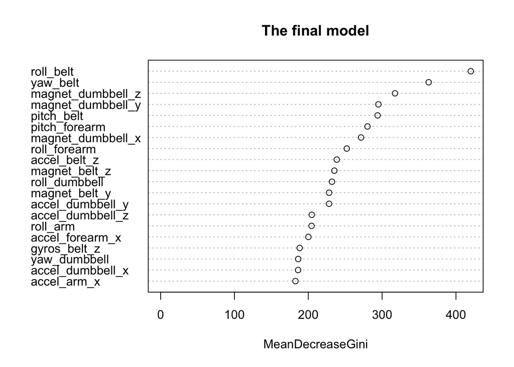

```r
varImpPlot(modfit$finalModel, n.var = 20, main = "The final model")
```

# 4 Final Prediction

We apply our model to the original test data and make the following predictions, and then write them to a text files.

```r
answers <- as.character(predict(modfit, test_final)); answers
```

```
##  [1] "B" "A" "B" "A" "A" "E" "D" "B" "A" "A" "B" "C" "B" "A" "E" "E" "A"
## [18] "B" "B" "B"
```

```r
pml_write_files = function(x) {
    n = length(x)
    for (i in 1:n) {
        filename = paste0("problem_id_", i, ".txt")
        write.table(x[i], file = filename, quote = FALSE, row.names = FALSE,
            col.names = FALSE)
    }
}

pml_write_files(answers)
```

# 5 Conclusion

We chose to build a model using a random forest because it tends to be an accurate mode. We increased the robustness of the model by using $k$-fold cross validation. This model has a high out-of-sample accuracy, and correctly predicted the 20 cases in the original test data.